# Contribuciones a OpenStreetMap en Ecuador: antes y después del terremoto 16A

Open Data Day Quito - 7 de marzo de 2020

## Introducción a OpenStreetMap

- Un esfuerzo internacional iniciado en 2004, para mantener una fuente de datos libres, disponibles a través de un mapa (Goodchild 2007).
- Más de 300 aplicaciones dependen parcial o totalmente de estos datos.

[figure not shown]

- Prevalecen dudas sobre aspectos de calidad; estos deben ser evaluados en cada lugar donde ha llegado el proyecto (Jokar Arsanjani et al. 2015).
- Posee aspectos de Big Data: volumen, velocidad, variedad (Goodchild 2013).

## Trabajo previo

Se infirió la escala a partir de vías OSM en administraciones zonales del DMQ.

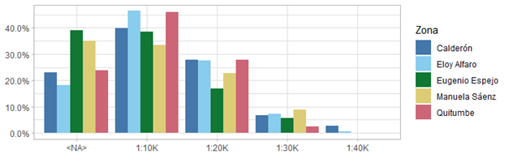

Metodología (Castro 2019):

1. Búsqueda de equivalencias con la cartografía oficial (vecino más cercano)
2. Cálculo de la exactitud posicional horizontal
3. Generación de polígonos de Voronoi en las intersecciones viales
4. Inferencia del módulo de escala, según norma nacional, para cada polígono

## Interrogantes…

- ¿Cómo se encuentran los demás aspectos de calidad?
- ¿Quiénes aportaron esos datos? ¿Cómo lo hicieron?
- ¿Para qué aplicaciones se encuentran aptos esos datos?
- ¿Están relacionados con cierto evento colaborativo masivo? (Neis 2020)

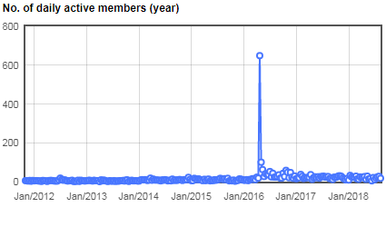

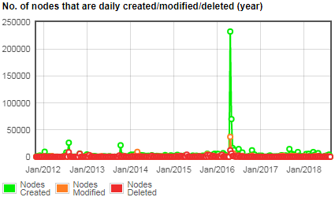

## [Mapping Ecuador](https://llactalab.ucuenca.edu.ec/eventos-2/mappingecuador/)

Contó con el apoyo del [Humanitarian OpenStreetMap Team](https://www.hotosm.org/projects/ecuador_earthquake) y contribuyó a mejorar la cartografía en zonas afectadas (Pedernales, Portoviejo, Manta, Chone…) por el terremoto del 16 de abril de 2016 en el litoral ecuatoriano.

[figure not shown]

> *“Hasta el momento, a 24 días del desastre, Mapping Ecuador cuenta con más de 2300 voluntarios digitales que han mapeado alrededor de 2.9 millones de objetos mediante la captura de imágenes satelitales.”* (Ullauri 2016)

## Obtención de datos OSM

- planet.osm / diff files / extract files (e.g. [Geofabrik](https://download.geofabrik.de/))
- Overpass API (e.g. [Kumi Systems](https://overpass.kumi.systems/))
- ¿web scraping? Se plantea realizarlo en lenguaje R:

```r
library(purrr)

get_day = possibly(function(day, url){

   message("Day: ", day)

   df = paste0(url, day) %>%
      httr::GET() %>%
      httr::content(encoding = "UTF-8") %>%
      xml2::as_list() %>%
      plucking() %>%
      map(framing) %>%
      reduce(rbind)

   df$date = day

   return(df)}, NULL)
```

## Obtención de datos OSM: vía web scraping

[figure not shown]

```r
days = as.Date("2011-11-1") + 0:2922 # 1 nov 2011 - 1 nov 2019

neis = "https://osmstats.neis-one.org/?item=countries&date="

countries = map(days, get_day, url = neis) %>% reduce(rbind)
```

## Aplicación: tasa diaria de nodos creados

El web scraping arrojó 738 mil observaciones (2917 días por 253 países o territorios). Se ajustó un modelo lineal para cada país; el siguiente mapa coroplético presenta la pendiente (i.e. la tasa de nodos por día) ajustada.

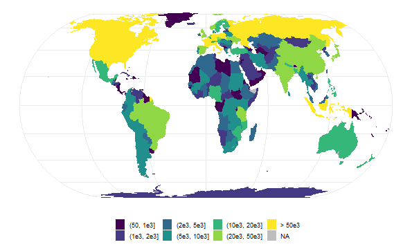

## Tasa de creación en Ecuador (un modelo)

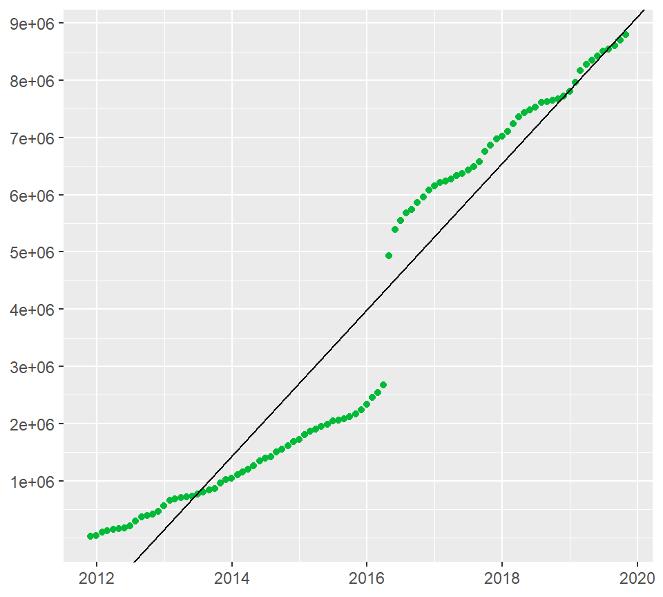

\(R^{2} = 0.9325\)

Nodos por día:

\(m_{ec} \approx 3500\)

\(\bar{m} \approx 9275\)

Nodos por día por 1000 Km<sup>2</sup>:

\(m_{ec} = 13.90\)

\(\bar{m} = 48.93\)

## Tasa de creación en Ecuador (dos modelos)

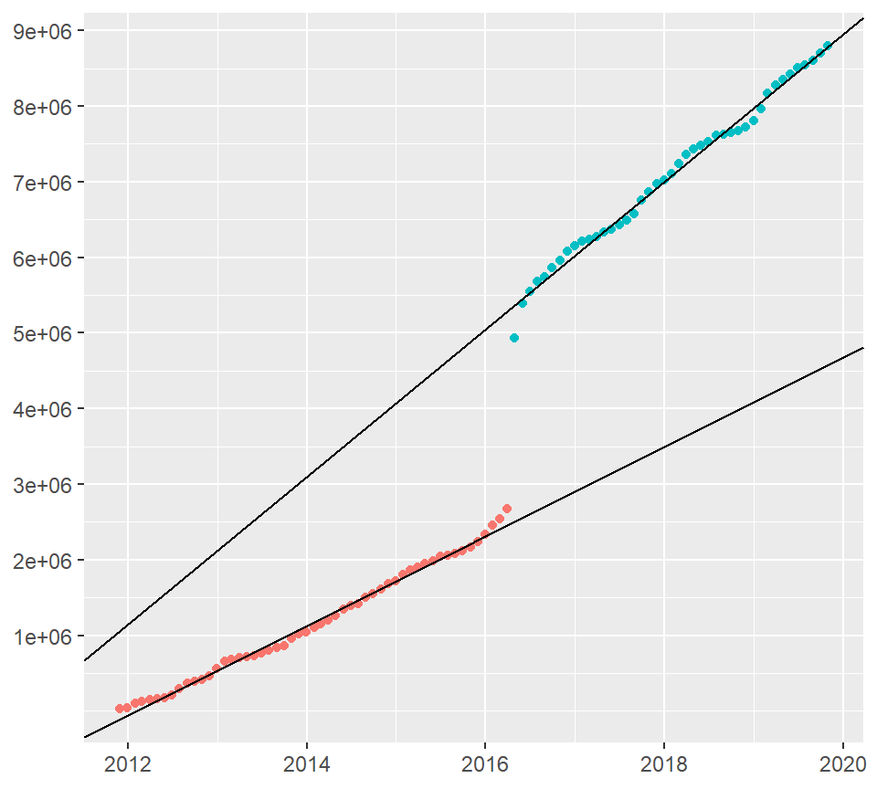

\(R^{2}_{1} = 0.9924\)

\(R^{2}_{2} = 0.9895\)

Nodos por día:

\(m_{1} \approx 1620\)

\(m_{2} \approx 2670\)

## Nodos y usuarios diarios (agregados anualmente)

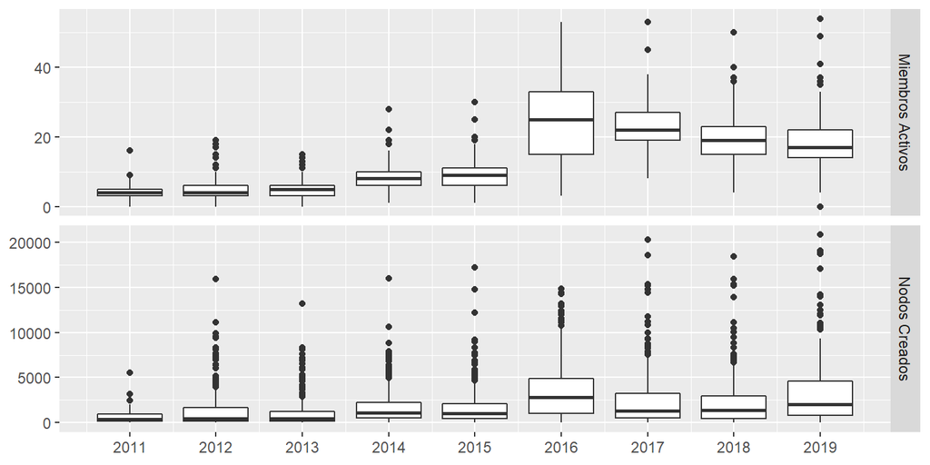

## Nodos y usuarios (agregados mensualmente)

La recta representa la mediana, la franja gris el IQR:

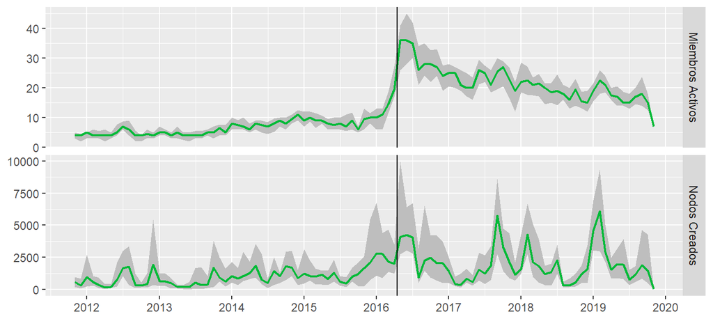

## Obtención de datos OSM: vía Overpass API

Del 18 al 28 de abril de 2016 son las únicas fechas en que se superó 80000 nodos creados por día.

Obtener los nodos creados en el país del 17 al 29 de abril:

```r
[out:csv(::id,::lat,::lon,::timestamp,::user,source)];
is_in(0,-78);
area._[admin_level="2"];
node(area._);
node._(changed:"2016-04-17T00:00:00Z","2016-04-29T00:00:00Z");
out meta;
```

Obtener los nodos creados en el país por el usuario “GeoFrizz”:

```r
[out:csv(::id,::lat,::lon,::timestamp)];
is_in(0,-78);
area._[admin_level="2"];
node(area._);
node._(user:"GeoFrizz");
out meta;
```

## Usuarios más activos en #MappingEcuador

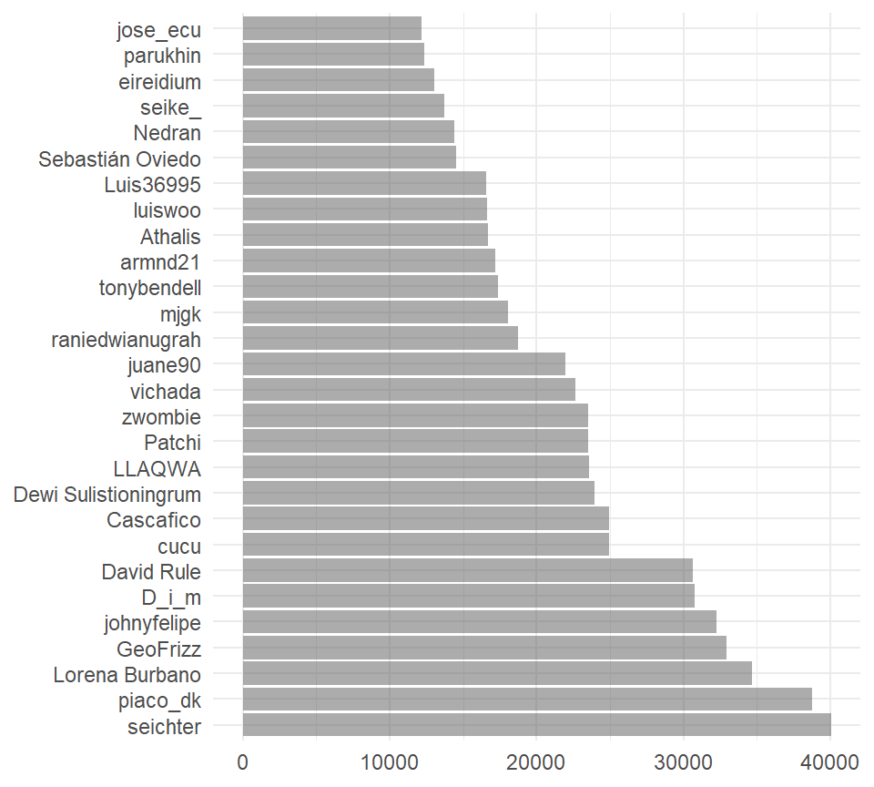

Total de usuarios diferentes: 3011

Total de nodos creados: 2003990

Nodos creados por los 28 usuarios más activos: 630893 (31.48 %)

De los 28, tres han estado activos en los últimos dos meses (Neis 2020):

- jose_ecu
- LLAQWA
- Cascafico

## Contribuciones del usuario: GeoFrizz

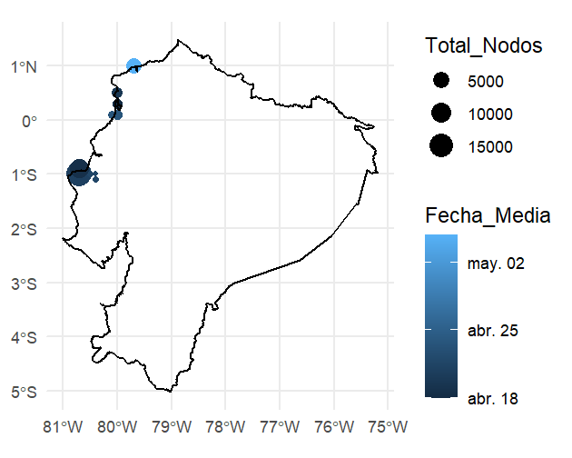

## Contribuciones del usuario: David Rule

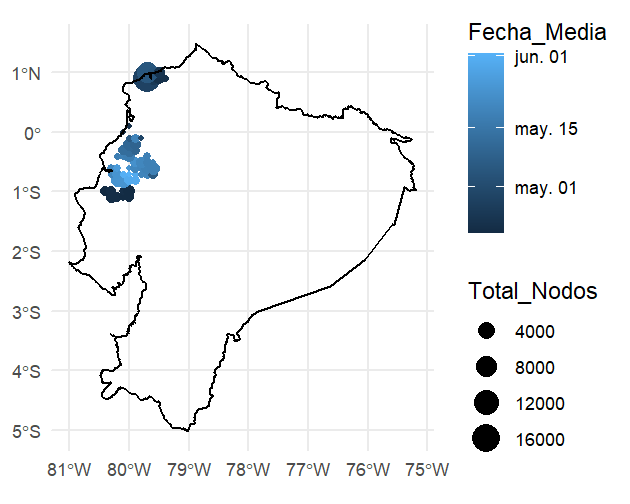

## Contribuciones del usuario: seichter

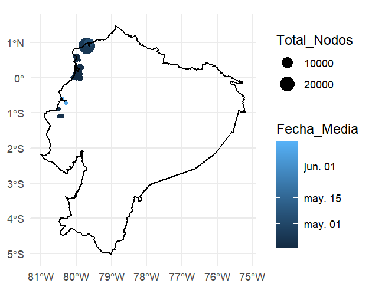

## Contribuciones del usuario: Cascafico

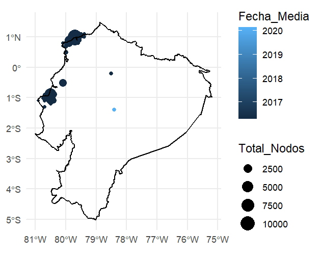

## Contribuciones del usuario: jose_ecu

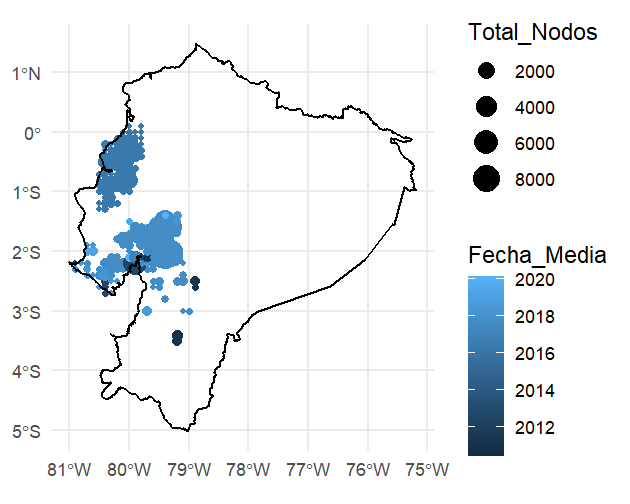

## Contribuciones del usuario: LLAQWA

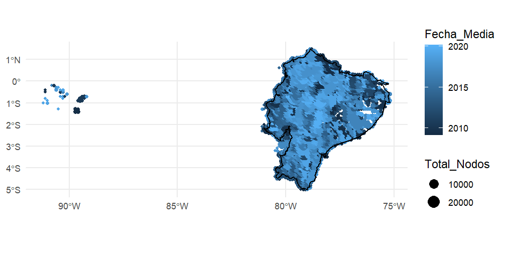

## Conclusiones

- La tasa de contribución diaria a OpenStreetMap en Ecuador se encuentra por debajo de la media mundial, incluso considerando la extensión del país.
- Las contribuciones están marcadas por un único evento masivo; la tasa diaria de creación de nodos se puede considerar mayor después de este evento.
- El incremento en las contribuciones es más evidente cuando se observa el número diario de usuarios activos.
- MappingEcuador tuvo una gran acogida, pero parece que muchos de los principales colaboradores no volvieron a contribuir a OpenStreetMap.
- Los usuarios que siguieron contribuyendo después de MappingEcuador probablemente ya eran activos antes de esta iniciativa.
- Cabe recordar que este análisis no consideró otras formas de contribución, como la modificación de nodos, o la creación de vías y relaciones.
- Otros aspectos de calidad, como el temático deben ser analizados igualmente.

## Referencias

Castro, Roger. 2019. “Evaluación de La Exactitud Posicional Horizontal E Inferencia de La Escala Sobre Datos Libres Osm En Administraciones Zonales Del Dmq.” Universidad de las Fuerzas Armadas - ESPE: Departamento de Ciencias de la Tierra y de la Construcción. https://repositorio.espe.edu.ec/handle/21000/20562.

Goodchild, Michael. 2007. “Citizens as Sensors: The World of Volunteered Geography.” *GeoJournal* 69 (August): 211–21. https://doi.org/10.1007/s10708-007-9111-y.

———. 2013. “The Quality of Big (Geo)data.” *Dialogues in Human Geography* 3 (December): 280–84. https://doi.org/10.1177/2043820613513392.

Jokar Arsanjani, Jamal, Alexander Zipf, Peter Mooney, and Marco Helbich. 2015. “An Introduction to Openstreetmap in Geographic Information Science: Experiences, Research, and Applications.” In *Lecture Notes in Geoinformation and Cartography*, 1–15. https://doi.org/10.1007/978-3-319-14280-7_1.

Neis, Pascal. 2020. “OSMstats - Statistics of the Free Wiki World Map.” March 6, 2020. https://osmstats.neis-one.org/.

Ullauri, Boris. 2016. “Mapping Ecuador Consolida La Logística En Zonas Afectadas Por El Terremoto.” Edited by IMPAQTO. May 12, 2016. https://www.impaqto.net/mapping_ecuador.